# COVID-19 Data Analysis and Insights

Chris Bunker

2024-12-07

# 1 Introduction

The Covid-19 Pandemic was one of the most significant events of the 21st century. It affected people from across the globe, regardless of socio-economic status. The pandemic was believed to have originated in Wuhan, China and after spreading rapidly, was officially designated a pandemic by the World Health Administration.

As of April 13, 2024, over 7 million people have died as a direct result of Covid-19, with the disease affecting the elderly and immune-compromised the most significantly.

It has long been known that diseases do not affect different populations equitably. Countries considered to be “second-world” or “third-world” historically have faced extreme disparities in medical treatment when compared to those considered “first-world”. For instance, in the United States there was an estimated 9,615 cases of TB in 2023, which is a significant number. However, in Indonesia, a country with a population around 50 million people less than the US, experienced 821,000 thousand cases of TB in 2023.

The purpose of my data analysis using a publicly available Covid dataset from https://ourworldindata.org/coronavirus is to explore the relationship between economic status and country, to see if the trend that has historically existed, exists with Covid-19 as well.

However, I will also be keeping in mind important information, such as the bias of data collection, where data collection methods are more prominent and tend to be more accurate in first world nations. Also keeping in mind the bias to for research and medical treatment to support first world nations rather than third world nations.

Below are references used in this passage:

Northwestern Medicine. (n.d.). COVID-19 pandemic timeline. Retrieved from https://www.nm.org/healthbeat/medical-advances/new-therapies-and-drug-trials/ covid-19-pandemic-timeline#:~:text=By%20March%202020%2C%20the%20World, COVID%2D19%20outbreak%20a%20pandemic.

Worldometer. (n.d.). Coronavirus death toll. Retrieved from https://www.worldometers.info/coronavirus/coronavirus-death-toll/

Centers for Disease Control and Prevention (CDC). (2023). Mortality in the United States, 2021. Retrieved from https://www.cdc.gov/mmwr/volumes/73/wr/mm7312a4.html

USAID. (2024). Indonesia tuberculosis roadmap narrative. Retrieved from https://www.usaid.gov/sites/default/files/2024-01/ Indonesia_TB_roadmap_narrative-22_edits_508.pdf —

# 2 Data and Methods

The data contained Covid related information on around 250 countries throughout the world. Depending on the specific analysis, some of these countries did not have sufficient data while most did.

The data set recorded data on a daily interval between the period of January 1st 2020 until February 2024. Data was also recorded for a total of 67 variables. However, for the purpose of this analysis, I focused on a time period that was relevant to the course of the pandemic, and variables that were not missing much data. For this reason, the data begins in January 2020 and ends April 25th 2022.

The variables I focus on are Country, GDP, total deaths, and total cases, as well as median age. I focus on these variables to get an idea for how the economic status of a country has a relationship with Covid cases and deaths. I also created my own variable, economic status, as a result.

For each of these countries I assigned a GDP Status category based upon GDP Per Capita where the lowest group had less than $10,000 USD GDP Per Capita, the second lowest having greater than $10,000, the third greater than $20,000, and the highest group having more than $35,000 USD GDP Per Capita.

## 2.1 Data Sources

The analysis is based on the following data: - **COVID-19 Data**: Sourced from [Our World in Data](https://ourworldindata.org/coronavirus). - **Geospatial Data**: Administrative boundaries from the Natural Earth dataset.

## 2.2 Methods

The visualizations in this report were generated using R and include: - Choropleth maps for geographic data visualization. - Scatterplots and histograms to explore relationships and distributions. - Bar plots to highlight economic indicators.

# 3 Analysis and Results

## 3.1 1. Economic Indicators: GDP Distribution by Country

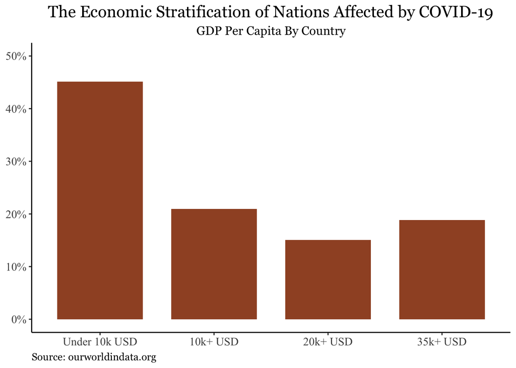

```r
readRDS("history_plot.rds")
```

## 3.2 2. Mortality Rates: Distribution of Reported COVID-19 Deaths

This histogram shows the distribution of deaths caused by Covid-19 by April 25th, 2022 per million people.

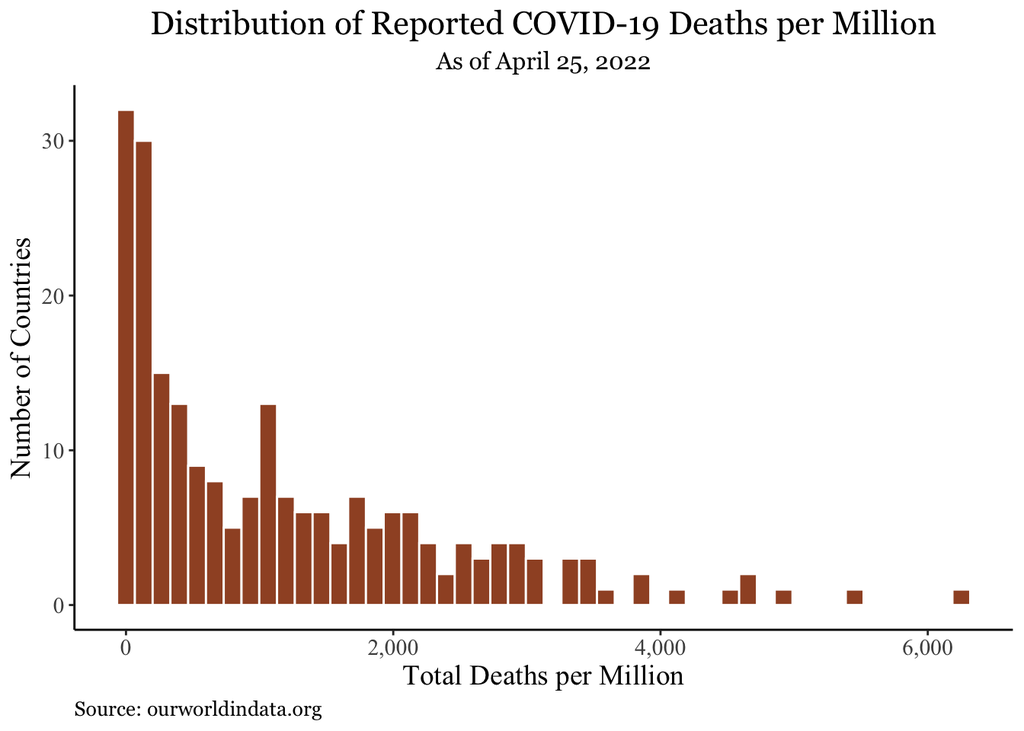

```r
readRDS("histogram_plot.rds")
```

*Key Observations*: As we can see, most countries appear to have deaths under 2,000 per million people. However, there is a significant right skew to the data with one value even greater than 6,000. Further analysis will reveal if economic status has a correlation to these outliers. Furthermore, I am skeptical of the data centered near and at zero and wonder instead if this is a problem with reporting.

## 3.3 3. Demographics: Relationship Between Median Age and COVID-19 Cases

This scatter plot looks at age, total cases per million people, and economic status for individual countries. Each dot represents and individual country. The median age represents the median age of the country’s population.

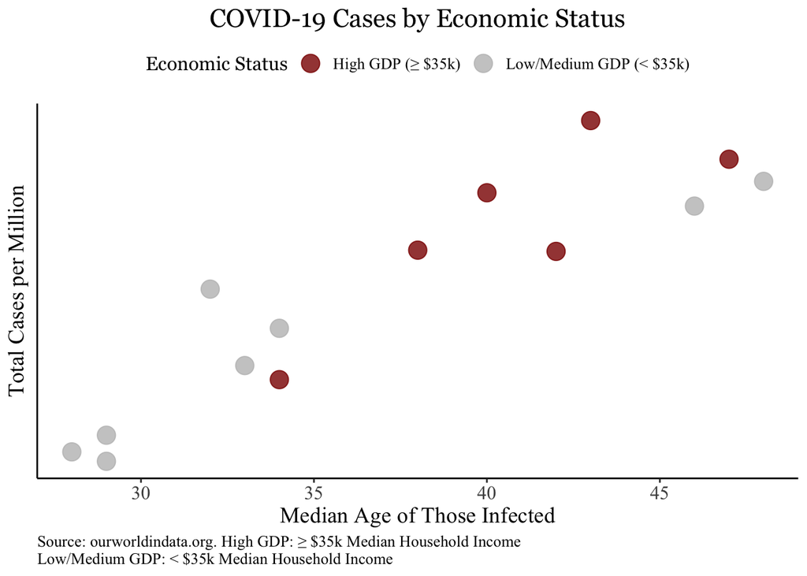

```r
readRDS("final_plot.rds")
```

*Key Observations*: Surprisingly, we see that high GDP countries have higher rates of Covid-19. This may be due to factors unique to wealthy individuals, such as the tendency to travel as well as the nature of Covid-19 which like other seasonal viruses such as the flu, tends to increase in transmission during the winter when people are stuck inside. Countries closer to the equator do not experience this issue, so as well as tending to have a lower GDP, also have a layer of protection from Covid-19. Like many viruses, it is also possible that Covid-19 simply performs better in one climate than the other. In this case, the protective factors for impoverished countries close to the equator tend to overcome the negating factors which historically have resulted in high levels of TB and other diseases.

## 3.4 4. Geographic Impact: COVID-19 Deaths in the Americas

This choropleth map highlights the geographic distribution of COVID-19 deaths across the Americas, focusing on Central and South America.

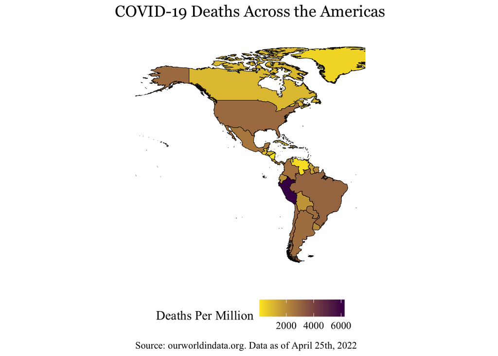

```r
readRDS("map_americas.rds")
```

However, what we do see is one clear outlier: Peru. After further research, I found that Peru had the world’s highest Covid death rate. At the time Covid hit Peru in early 2020, Peru was already being hit by a massive wave of Dengue fever, rendering the medical sector incapable of adequately responding to Covid. Furthermore, Peru’s medical system ran out of oxygen which was necessary to keep patients in a severe state alive. Other factors such as the informal economy and housing crisis in Peru expedited the spread of the virus as well.

# 4 Discussion

My analysis and visualization reveals that economic status can play a role in cases and deaths from Covid-19. However, the relationship is not linear, and more descriptive than causal.

For instance, a lack of medical supplies and overcrowding definitely were a significant cause of deaths in Peru. However, this is not a trend that is uniform throughout the data.

Rather, the seasonality of the virus and increased transmission during the winter may likely be a significant factor working against so called “first world nations”. As we saw in the scatter plot, first world nations tended to represent a significant portion of the global Covid-19 cases. Impoverished countries, with a skew towards the global south, appear to have a layer of protection due to their lack of seasons. However, other factors such as overcrowding and lack of medical supplies and treatment tend to balance out with northern countries. This results in a chloropeth (map) that shows a somewhat indiscriminate trend, where economic status and deaths caused by Covid do not seem correlated.

# 5 Conclusion

Overall, there is not significant evidence to suggest that economic status is a driving force for the number of cases or deaths caused by Covid-19, except in the case of Peru where this is significant evidence suggesting that a lack of medical supplies were directly responsible for the largest death toll by Covid-19 globally.

# 6 References

1. [Our World in Data: COVID-19](https://ourworldindata.org/coronavirus)
2. [Natural Earth Dataset](https://www.naturalearthdata.com/)
3. [Github Project Repository](https://github.com/cbunker8/Covid-Analysis.git)

## 6.1 Code and Reproducibility

The R code used to generate the visualizations in this report is available in the repository. Readers can reproduce the analysis by running the scripts provided.